# Monday, March 30th, 2026

Last class, we worked on creating tartan pattern images.

```python
import numpy as np
import matplotlib.pyplot as plt
```

## [Project 3: Tartans](https://jllottes.github.io/Projects/tartans/tartans.html) (cont.)

We've been working with the following example tartan recipe.

Pattern :

> B14 K6 B6 K6 B6 K32 OG32

where the colors B, K, and OG are given by the RGB triples:

> B : [52, 80, 100]  
> K : [16, 16, 16]  
> OG : [92, 100, 40]

In particular, we worked to create code that would take lists `widths` and `colors` and use them to produce

- a `vertical_stripes` RGB image array,
- a `horizontal_stripes` RGB image array,
- a `checkerboard_tartan` RGB image array, and (possibly)
- an `authentic_tartan` RGB image array.

Last week, we manually generated the `widths` and `colors` lists. It would be convenient if we could use Python to automatically generate these lists directly from the tartan recipe.

### String processing

In generating our tartan images, we interpreted the tartan recipe by defining lists for the widths and colors. It would be nice if we could use Python to generate the list of widths and colors automatically. In other words, it would be convenient if we could define a string like `tartan_recipe = 'B14 K6 B6 K6 B6 K32 OG32'` and process this string to pull out these two lists.

```python
tartan_recipe = 'B14 K6 B6 K6 B6 K32 OG32'
```

We have already seen some useful tools for working with strings in Python. For example:

- The `.join` method allows us to concatenate a list of strings using a given string as a separator.
- The `.format` method allows us to plug values into a string template.

Another helpful tool is the `.split` method, which allows us to separate a string into a list of substrings. The syntax is something like:

> `some_string.split(some_separator)`

This will separate the `some_string` string into a list of substrings, where each separation occurs whenever the `some_separator` string is found within `some_string`.

```python
some_string = 'Hello, this is a fine Monday.'

some_string.split(' ')
```

```
['Hello,', 'this', 'is', 'a', 'fine', 'Monday.']
```

```python
some_string.split('s')
```

```
['Hello, thi', ' i', ' a fine Monday.']
```

Note: If we call the `.split` method with no input variable, by default the string will be split anywhere there is white space (e.g. spaces, tabs, line breaks, etc.).

```python
some_string = 'This string has    some extra     spaces.'
some_string.split(' ')
```

```
['This',
 'string',
 'has',
 '',
 '',
 '',
 'some',
 'extra',
 '',
 '',
 '',
 '',
 'spaces.']
```

```python
some_string.split()
```

```
['This', 'string', 'has', 'some', 'extra', 'spaces.']
```

We can then apply the `.split` method to the `tartan_recipe` string to get a sequence of substrings, each of which represents a particular stripe.

```python
tartan_stripe_recipes = tartan_recipe.split()
print(tartan_stripe_recipes)
```

```
['B14', 'K6', 'B6', 'K6', 'B6', 'K32', 'OG32']
```

Can we iterate through each of these stripe recipes and pick out the color and width?

```python
for tartan_stripe_recipe in tartan_stripe_recipes:
    print(tartan_stripe_recipe)
```

```
B14
K6
B6
K6
B6
K32
OG32
```

Problem: We can't just take the first character from `stripe_recipe` as the color code, because some color codes have two characters (e.g. `'OG'`).

It would be very helpful if we could pick out which parts of a string are letters and which parts of a string are numbers. The following methods (called on a string) can help with this:

- The `.isalpha` method will return `True` if the string contains only alphabetic characters (i.e. letters).
- The `.isnumeric` method will return `True` if the string contains only numeric characters (i.e. numbers).

```python
'123456'.isnumeric()
```

```
True
```

```python
'123a456b'.isnumeric()
```

```
False
```

```python
'FiveSixSeven'.isalpha()
```

```
True
```

```python
'Five6Seven'.isalpha()
```

```
False
```

**Exercise:** Write a function that takes in a tartan recipe string and returns a list of color codes (e.g. `['B', 'K', 'B', ...]`) and widths.

```python
color_codes = []
widths = []

for tartan_stripe_recipe in tartan_stripe_recipes:
    color_code = ''
    width_str = ''
    for char in tartan_stripe_recipe:
        if char.isalpha():
            color_code += char
        if char.isnumeric():
            width_str += char
    color_codes.append(color_code)
    widths.append(int(width_str))

print(color_codes)
print(widths)
```

```
['B', 'K', 'B', 'K', 'B', 'K', 'OG']
[14, 6, 6, 6, 6, 32, 32]
```

```python
color_codes = []
widths = []

for tartan_stripe_recipe in tartan_stripe_recipes:
    color_code = []
    width_str = []
    for char in tartan_stripe_recipe:
        if char.isalpha():
            color_code.append(char)
        if char.isnumeric():
            width_str.append(char)
    color_codes.append(''.join(color_code))
    widths.append(int(''.join(width_str)))

print(color_codes)
print(widths)
```

```
['B', 'K', 'B', 'K', 'B', 'K', 'OG']
[14, 6, 6, 6, 6, 32, 32]
```

From the above, we can pick out the color code strings from the tartan recipe. On the other hand, in order to generate our `vertical_stripes` array, we need to get the corresponding RGB triples (not just the color code strings). How can accomplish this?

```python
color_codes
```

```
['B', 'K', 'B', 'K', 'B', 'K', 'OG']
```

```python
B = [52, 80, 100]
K = [16, 16, 16]
OG = [92, 100, 40]

colors = []
for color_code in color_codes:
    if color_code == 'B':
        colors.append(B)
    elif color_code == 'K':
        colors.append(K)
    elif color_code == 'OG':
        colors.append(OG)

print(colors)
```

```
[[52, 80, 100], [16, 16, 16], [52, 80, 100], [16, 16, 16], [52, 80, 100], [16, 16, 16], [92, 100, 40]]
```

It would be convenient if we could define a mapping that maps each color code to its respective RGB triple.

### Dictionaries

Let's consider a list, `my_list`.

```python
my_list = ['Hello', 'World', 'Goodbye', 7]
```

We can think of `my_list` as a mapping between indices `0`, `1`, `2`, `3`, and values `'Hello'`, `'World'`, `'Goodbye'`, `7`. That is, we have the following mappings:

- index `0` maps to value `'Hello'`,
- index `1` maps to value `'World'`,
- index `2` maps to value `'Goodbye'`,
- index `3` maps to value `7`.

To retrieve values of a list, we can "plug in" an index using square brackets `[]`:

```python
my_list[0]
```

```
'Hello'
```

```python
my_list[2]
```

```
'Goodbye'
```

A Python *dictionary* works very similarly, except that instead of a map from indices to values, we have a map from *keys* to values. These keys do not need to be integers `0`, `1`, `2`, ..., but are more flexible. Dictionary keys can include integers, floats, strings, tuples, functions, and many other types (anything that is *immutable*).

To define a dictionary, we can use curly braces `{}` containing a comma-separated sequence of `<key>:<value>` mappings. For example, suppose we want to construct a dictionary with the following mappings:

- key `5` maps to value `'Hello!'`,
- key `(0,255,0)` maps to `'Green'`,
- key `'Good'` maps to value `10`,
- key `'Bad'` maps to value `0`,
- key `'Red'` maps to value `(255,0,0)`.

```python
my_dict = {5: 'Hello!',
           (0,255,0): 'Green',
           'Good': 10,
           'Bad': 0,
           'Red': (255,0,0)}
```

Just like with lists, we can "plug in" a key to the dictionary and retrieve the corresponding value using square brackets `[]`.

```python
my_dict[5]
```

```
'Hello!'
```

```python
my_dict['Red']
```

```
(255, 0, 0)
```

Note: unlike lists , we cannot use slicing with dictionaries. This is because the dictionaries do not have any inherent order in Python.

If desired, we can access the keys of a dictionary using the `.keys` method. Similarly, we can access the values using the `.values` method. Finally, we can access key/value pairs using the `.items` method.

```python
for key in my_dict.keys():
    print(key)
```

```
5
(0, 255, 0)
Good
Bad
Red
```

```python
for value in my_dict.values():
    print(value)
```

```
Hello!
Green
10
0
(255, 0, 0)
```

```python
for key, value in my_dict.items():
    print(key, value)
```

```
5 Hello!
(0, 255, 0) Green
Good 10
Bad 0
Red (255, 0, 0)
```

This allows us to iterate through dictionaries in several ways:

- `for key in my_dictionary.keys()` will iterate through each key of the dictionary. We can also write `for key in my_dictionary`, which will still iterate through the keys.
- `for value in my_dictionary.values()` will iterate through each value of the dictionary.
- `for key, value in my_dictionary.items()` will iterate through each key/value pair.

**Exercise:** Write a dictionary whose keys are the color codes `'B'`, `'K'`, and `'OG'` and whose values are the corresponding RGB triples.

```python
color_dict = {'B': [52, 80, 100],
              'K': [16, 16, 16],
              'OG': [92, 100, 40]}
```

**Exercise:** Use the `color_codes` list and the above dictionary to construct a list `colors` containing the RGB triples for each stripe in the tartan recipe.

```python
colors = []
for color_code in color_codes:
    colors.append(color_dict[color_code])

print(colors)
```

```
[[52, 80, 100], [16, 16, 16], [52, 80, 100], [16, 16, 16], [52, 80, 100], [16, 16, 16], [92, 100, 40]]
```

### Remaining tasks to be addressed for Project 3:

- We have explicitly discussed how to combine the `vertical_stripes` and `horizontal_stripes` arrays in a checkerboard pattern. For the project, we will need to use the more authentic pattern described on the project page to combine these arrays and generate our tartan image.
- We are told to recreate a tartan image that is `500` rows by `500` columns. On the other hand, the tartan recipe does not add up to a total width of `500`. We will need to think about how to repeat the pattern to fill the entire `(500, 500, 3)` array.

## [Project 4: Image denoising](https://jllottes.github.io/Projects/image_denoising/image_denoising.html)

In recent weeks, we've been working with images using `(m,n,3)`-shaped NumPy RGB arrays and visualizing them with `plt.imshow`. The cell below will download an example image file from the course webpage into your Jupyter notebook directory with the file name `noisy_img.png`.

```python
import requests

with open('noisy_img.png','wb') as f:
    data = requests.get(r'https://jllottes.github.io/_images/noisy_img.png').content
    f.write(data)
```

Let's read this image in as a NumPy array using `plt.imread` and plot it using `plt.imshow`:

[figure not shown]

```python
noisy_img = plt.imread('noisy_img.png')
plt.imshow(noisy_img)
```

Notice that the image looks to have been affected by some kind of noise. In particular, some pixels seem to have mistakenly been colored white, while others have been colored black. Let's take a closer look to see this more clearly.

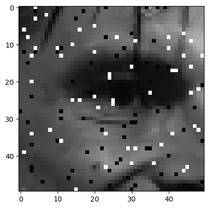

```python
plt.imshow(noisy_img[130:180,265:315])
```

This type of noise is called *salt and pepper noise*, where some pixels have been replaced with white (salt) pixels and other pixels have been replaced with black (pepper) pixels. For our next project, we are interested in exploring strategies to try to filter and remove this type of noise.

### Loading in sample images

In order to explore filtering salt and pepper noise, it's useful to first be able to generate this kind of noise ourselves. That is, it will be helpful to have some Python code that can take an image and randomly assign some pixels to be salt noise and others to be pepper noise.

For example, I've downloaded `circuit.png` into my Jupyter notebook directory. Now, I will read it into a NumPy array:

```python
circuit = plt.imread('circuit.png')
```

Let's use `plt.imshow` to see what this image looks like.

[figure not shown]

```python
plt.imshow(circuit)
```

Before proceeding, let's take a look at the structure of the `img` array. For example, does it contain RGB values or RGBA values (with transparency)? Does it contain floats between `0` and `1` or does it contain integers between `0` and `255`?

```python
circuit.shape
```

```
(426, 640, 3)
```

```python
circuit.dtype
```

```
dtype('float32')
```

We see that the `circuit.png` image contains floating point RGB values (without transparency). If your chosen image has a different format, transform it so that it also contains floating point RGB values. As a reminder:

- `img[:,:,:3]` will produce a slice consisting of only the RGB parts of the image and will drop any transparency information, and
- `img / 255` produce a floating point RGB array from an integer RGB array.

### Grayscale images

For this project, we will be working with grayscale images. That is, each image contains only shades of gray.

Note: we get a shade of gray when the red, green, and blue channels match for a given pixel. Let's confirm that our image file contains only gray pixels.

```python
np.min(circuit[:,:,0] == circuit[:,:,1])
```

```
np.True_
```

```python
np.min(circuit[:,:,0] == circuit[:,:,2])
```

```
np.True_
```

We can represent grayscale images as `(m,n)` arrays (rather than `(m,n,3)`) without any loss of information, since all three color channels give the same `(m,n)` array. In the case of the `img` array, we could take `img[:,:,0]` (the red channel) to represent the grayscale values.

```python
gray_circuit = circuit[:,:,0]
```

Let's confirm that there's no loss of information:

[figure not shown]

```python
plt.imshow(gray_circuit)
```

Recall: when `plt.imshow` is passed a grayscale array, it defaults to the `viridis` colormap. Let's override this choice to use the `gray` colormap. It would also be helpful to specify `vmin=0` and `vmax=1` (or `vmax=255` if working with integer data) to ensure that `plt.imshow` is correctly assigning colors to the values in the array.

[figure not shown]

```python
plt.imshow(gray_circuit, cmap='gray', vmin=0, vmax=1)
```

What could we do if we started from a color image that we want to convert to a grayscale image, like `mario.png`?

[figure not shown]

```python
mario = plt.imread('mario.png')
plt.imshow(mario)
```

The above image does not contain purely grayscale data, since the red/green/blue values do not match for at least some of the pixels. Can we construct a reasonable grayscale version of this image?

```python
np.min(mario[:,:,0] == mario[:,:,1])
```

```
np.False_
```

[figure not shown]

```python
gray_mario = mario[:,:,0]

plt.imshow(gray_mario, cmap='gray', vmin=0, vmax=1)
```

The `np.mean` function can be used to compute averages of an array.

```python
#help(np.mean)
```

```python
np.mean(mario)
```

```
np.float32(0.67915136)
```

For our purposes, we don't want to take the average value of every value in the `mario` array. Instead, we want to average the RGB triples separately for each pixel in the image.

We can include an optional argument `axis` to specify the dimension through which means should be calculated. In particular, including the argument `axis=2` tells NumPy to compute the average through the color channel only (i.e. axis `2` of the `(m,n,3)` array). In other words, this will average the RGB triple separately for each pixel.

```python
gray_mario = np.mean(mario, axis=2)

print(gray_mario.shape)
```

```
(224, 256)
```

[figure not shown]

```python
plt.imshow(gray_mario, cmap='gray', vmin=0, vmax=1)
```

### Adding salt and pepper noise

Before adding noise to our image, let's make a copy of the array to preserve the original image array. Let's call this copy `noisy_img` (we will come back to add noise to this image later).

```python
noisy_img = circuit.copy()
```

We would like a method for randomly selecting pixels of the `noisy_img` array to which we can add salt/pepper noise. The `np.random.random` function will be useful for this task, which works as follows:

- `np.random.random()` will return a randomly selected float in the interval $[0,1)$.
- `np.random.random(shape)` will return an array with shape `shape`, where each entry contains a randomly selected float in the interval $[0,1)$.

Strategy: let's generate an array of the same shape as our image filled with randomly drawn values between `0` and `1`. If the randomly drawn value is greater than, say `.9`, we'll add salt noise in that position.

```python
np.random.random()
```

```
0.44274203198272244
```

```python
np.random.random((3,4))
```

```
array([[0.01092382, 0.78408415, 0.91518509, 0.84863303],
       [0.75876538, 0.13768678, 0.72340887, 0.70300808],
       [0.40025806, 0.41402923, 0.48853017, 0.4697628 ]])
```

```python
def imshow_gray(a):
    plt.imshow(a, cmap='gray', vmin=0, vmax=1)
```

[figure not shown]

```python
nrows, ncols = gray_circuit.shape

noisy_img = gray_circuit.copy()

random_array = np.random.random((nrows, ncols))
for row in range(nrows):
    for col in range(ncols):
        if random_array[row, col] > .9:
            noisy_img[row, col] = 1

imshow_gray(noisy_img)
```

What if we want to add pepper noise as well?

[figure not shown]

```python
nrows, ncols = gray_circuit.shape

noisy_img = gray_circuit.copy()

salt_array = np.random.random((nrows, ncols))
pepper_array = np.random.random((nrows, ncols))

for row in range(nrows):
    for col in range(ncols):
        if salt_array[row, col] > .9:
            noisy_img[row, col] = 1
        if pepper_array[row, col] > .9:
            noisy_img[row, col] = 0

imshow_gray(noisy_img)
```

*Note*: In the example code above, we iterated through every row and column and decided for each entry whether or not to add salt and pepper noise. This is perfect case to use Boolean arrays.

*Idea*: create a `salt_mask` Boolean array containing `True` in each entry that we wish to hit with salt noise. That is, `salt_mask` should contain `True` everywhere that the `random_array` is less than, say, `0.1`.

**Exercise.** Use the above sample code to write a function `sp_noise(img, noise)` that adds salt and pepper noise to an image. Its first argument `img` should be a 2-dimensional numpy array representing the image and the second argument `noise` should be the fraction of pixels that are to be replaced by noise (for example, with `noise = 0.05` about 5% of pixels should be noise, consisting in roughly equal parts of white and black pixels). The function should return a 2-dimensional numpy array representing the original image with noise added.